# PCA

Oxana Kolpakova

06 12 2021

We need to predict the critical temperature of the superconductor (column critical_temp) from various characteristics of the substance and its composition (all other columns).

Load the necessary libraries.

Removing workspace stuff.

```r
rm(list = ls())
```

Specify the URL of the archive.

```r
url_zip <- "https://archive.ics.uci.edu/ml/machine-learning-databases/00464/superconduct.zip"
```

Download and unzip data.

```r
path_unzip <- "C:/Users/1/Desktop/unzipped/data_archive.zip"
ifelse(!file.exists(path_unzip),
       download.file(url_zip, path_unzip, mode="wb"),
       'file alredy exists')
```

```
## [1] "file alredy exists"
```

```r
unzip(path_unzip, exdir = "C:/Users/1/Desktop/unzipped/.")
```

Import data.

Delete the column materials.

```r
unique_m = unique_m[,-88]
```

```r
data1 <- cbind(train,unique_m )
```

Delete dependent dublicate “critical_temp” column.

Remove predictors with near-zero variance.

Divide data into training and test samples.

```r
set.seed(101)
# create a vector with randomly selected observation numbers
tr.index = sample(1:nrow(data2), nrow(data2)*0.8)

#form a training sample,80%
trSet = data2[tr.index, ]

#form a control sample, 20%
testSet = data2[-tr.index, ]
```

Performe z-standardization on the training set as the preProcess() function: method = “center” subtracts the mean from the predictors, method = “scale” divides them by the standard deviation.

!The * _forLM sets contain the critical_temp variable. !The * _forPCA sets do not contain the critical_temp variable.

To apply transformations taking into account these estimated parameters, use the predict() function

Make a linear model that predicts the critical temperature for all available predictors, look at the adjusted R-squared.

```r
model <- lm(critical_temp ~ ., data=trSet_forLM)
#summmary(model)
summary(model)$adj.r.squared
```

```
## [1] 0.7435693
```

```r
pca_train <- prcomp(testSet_forPCA)
pca_train1 <- rda(testSet_forPCA)
```

How many PC components should we leave?

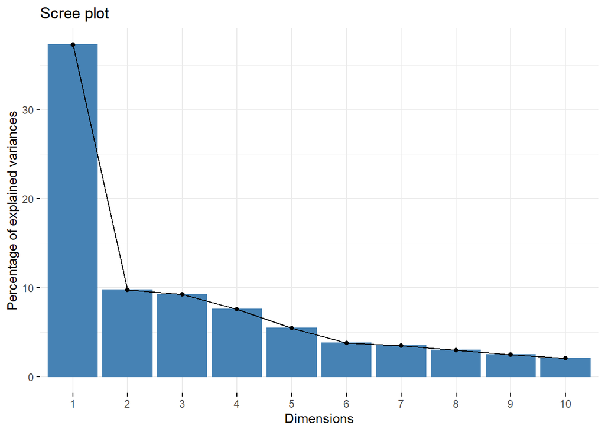

```r
fviz_eig(pca_train)
```

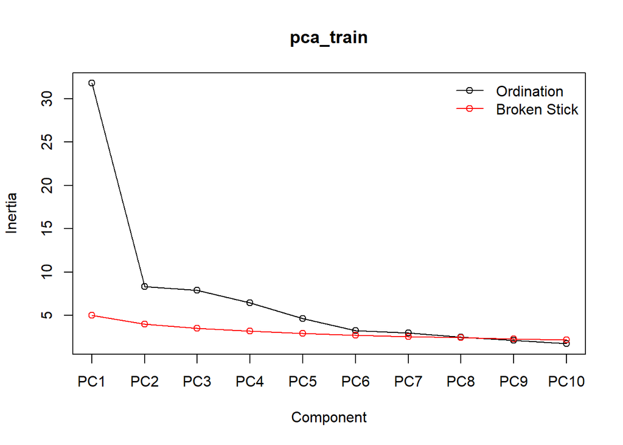

```r
#summary (pca_train)#  PC8 explains 79% of variance
screeplot(pca_train, type = "lines", bstick = TRUE) # it is necessary to leave PC8
```

Extract PCs.

```r
pca_scores<- as.data.frame(scores(pca_train, display = "species", choices = c(1:8), scaling = 0))
#str(pca_scores)
```

```r
trans_train_pca <- as.data.frame(as.matrix(trSet_forPCA) %*% as.matrix(pca_scores))

trans_test_pca <- as.data.frame(as.matrix(testSet_forPCA) %*% as.matrix(pca_scores))

trans_train_pca <- cbind(trans_train_pca, trSet_forLM[87])
trans_test_pca <- cbind(trans_test_pca, testSet_forLM[87])
#str(trans_test_pca)
```

Make new linear model.

```r
#model <- lm(critical_temp ~ ., data=trSet_forLM)
postPCA_model <- lm(critical_temp~., data=trans_test_pca)
#summary(postPCA_model)
summary(postPCA_model)$adj.r.squared # linear model got worse((
```

```
## [1] 0.5892925
```

#To improve the model, we decided to run a kernel PCA. #We ran out of memory for analysis.

```r
#kpca = kpca(~., data = trSet_forPCA, kernel = 'rbfdot', features = 2)
```

Download file of kernelPCs courtesy by Danil Linvinov

#I did not complete the analysis because #I could not convert the PCs_kernel% *% #testSet_forPCA matrix. #The provided X_kpca.npy file and my testSet_forPCA #have different number of observations. #I could not quickly solve this problem (( #I wrote code for further analysis.

#Linear modal with transformed data.

```r
#kernel_model <- lm(critical_temp~., data = trans_test_kernel)
#summary(kernel_model)
#summary(postPCA_model)$adj.r.squared
```